# Toxic Comment Classification

Umbrella Academy: Yutong Liu, Yu Gu, Beilin Jia, Hannan Yang, Mochuan Liu

4/24/2019

# 1 Introduction

Our project is inspired by the following competition from kaggle:  
https://www.kaggle.com/c/jigsaw-toxic-comment-classification-challenge/overview

Internet is now a very important part of our life, we could obtain knowledge, get most recent news update and entertainment. However, as it provides us convenience and pleasure, sometimes unfriendly comments or messages of others may upset people and make them less likely to go online, leave comments to posts or ask technical questions. Many platforms are now struggling about the problem that comments leave by users might be considered profane, vulgar, or offensive.

One possible approach of improving this is to develop methods and algorithms that could identify negative online behaviors (i.e. “toxic comments”), like comments that are rude, disrespectful or otherwise likely to make someone else to leave a discussion because of the threat of abuse or harassment. The Conversation AI team, a research initiative founded by Jigsaw and Google (both a part of Alphabet) are working on tools to help improve online conversation and they initiated this competition on Kaggle.

In this project, we aim to develop a method that is capable of detecting different types of toxicity such as threats, obscenity, insults and identity-based hate. Our training and testing datasets will both be of comments from Wikipedia’s talk page edits. We hope to develop a method which could help online discussion become more productive and respectful by successfully identify the “toxic” comments.

# 2 Data Description

We are provided with a large number of Wikipedia comments which have been labeled by human raters for toxic behavior. The types of toxicity are: toxic, severe toxic, obscene, threat, insult, identity_hate. The only type of toxicity (label) involved in the following analysis will be “toxic”. The training dataset is a 160k * 8 matrix containing id, text comment, and 6 types of toxicity. The text comments were stored as strings and contains meaningful covariates (like keywords or phrases) for toxicity classification.

**Examples of toxic and nontoxic comments**  
Toxic comment: *Bye! Don’t look, come or think of comming back! Tosser.*  
Nontoxic comment: *Congratulations from me as well, use the tools well.*

For the purpose of this project, our target label is “toxic”. We’re going to include all 15294 samples which were rated as “toxic”. We down-sampled the samples with “non-toxic” labels to have the same size as the “toxic” samples and form a new subset of the original training dataset, then restrict model training only on this subset. The testing dataset contains the comments from approximately 153k subjects, the true “toxic” labels for the subjects in the testing dataset are also provided so we may compute the misclassification error rate between the predicted and true “toxic” labels.

# 3 Methods

## 3.1 Preprocessing

The first step was to convert comments into features that we could use for our model. To do this, we used the R package “text2vec” to tokenize the data (split each sentence into words). Following tokenization, we applied stemming with the R package “SnowballC” which reduces inflections/variations of a word to a common root by slicing off the ends of words down to the maximum string contained in all variations (e.g. operate, operates, operation, operations, operated, all become “operat”). The most frequent words are often those which carry very little semantic weight (grammatical function words).[1] They were deleted with the help of R package “stopwords”.

We then applied count vectorization by 1) finding the vocabulary of length $p$, which contains all tokens, bigrams (of tokens) and trigrams (of tokens) that appear at least 10 times across all comments in the data; 2) for each comment, we get a vector of length $p$, where for each token/bigram/trigram in the vocabulary, the value is the number of times that said token appeared in the message.

## 3.2 LASSO → Random Forest, SVM

After preprocessing , we still have a large set of candidate “keywords”, which makes it hard to implement methods like random forest and svm. To solve this problem, we first use 10-fold cross validation and lasso to do variable selection, which selects 122 “keywords” to determine whether a comment is toxic or nontoxic. Then we use these selected “keywords” to do classification, with both random forest algorithm and svm algorithm. For the svm algorithm, we use both the linear kernel and the radial kernel. In this process, the most essential thing is to tune parameters with cross validation. We start with a large pool of candidate parameters for both of the two methods, thus it takes quite a long time to find the best tuning parameters.

## 3.3 Marginal Frequency → Random Forest, SVM

Another approach to do variable selection is to train among weak classifiers. In the negative-positive natural language classification problem, the sentiment tendency of a single sentence is, in general, the cumulative sentiment tendency of words/phrases with clear emotion implications. Similar idea can be applied to improve and accelerate the toxic/non-toxic classification problem by selecting words/phrases with a clear toxic/non-toxic tendency and restricting on selected features.

The main problem of this approach is to reasonably identify which words/phrases are toxic/non-toxic. From a machine learning perspective, each word/phrase with a clear emotion tendency can be viewed as a weak classifier in a 1-dimension space and a good weak classifier should at least have the minimum classification accuracy, that is, can correctly classify a sentence with probability strictly larger than 0.5; or equivalently, this is just to say that word/phrase with a clear toxic/non-toxic tendency should have different frequencies in toxic and non-toxic data. Following this idea, we propose a measure of frequency difference which is defined as
$$diff(w)=\frac{|f_{1}(w)-f_{2}(w)|}{max\{f_1(w),f_2(w)\}}$$

where $f_1(w)$ and $f_0(w)$ denote the word/phrase frequency in toxic and non-toxic respectively. The frequency difference can be estimated using training data and a word/phrase is said to have a clear toxic/non-toxic tendency if and only if $\hat{d}(w)>0.02$. In practice, we do similar preprocessing by tokenizing the data first and compute the frequency difference based on the tokenized frequency table. In addition to the frequency difference lower bound, to exclude rare keywords we also require that the total count of the given word/phrase should be larger than 10. For simplicity and practical consideration, we break the selected phrases into word lists. After variable selection, the final training data has 277 columns of total counts of 277 unique keywords for each training comments.

## 3.4 Application of EM Algorithm: Finite Mixture Logistic Regression

The previous datasets were obtained after selecting the keywords correlated to the label “toxic”: logistic regression with LASSO eliminated variables by $L_1$ penalization while marginal frequency thresholding eliminated variables that have similar distributions within toxic samples and non-toxic samples. Here one might be interested in checking if each of the selected variables (keywords) indeed has predictive values for classifying toxicity. We proposed a mixture model with two classes and model the occurrence of a specific keyword in each of the classes by logistic regression with offset (adjusting for the length of the comment). By estimating the parameters in the mixture model, one may calculate the posterior probabilities of falling into specific class given the occurrence of a specific keyword.

# 4 Results

We start by loading all the existing R packages we need as well as our own package “UmbrellaAcademy”.

```r
library(devtools)
library(caret)
library(glmnet)
library(ggrepel)
library(scales)
library(e1071)
library(ggplot2)
library(SparseM)
library(randomForest)
library(svMisc)
load_all("UmbrellaAcademy")
```

## 4.1 Preprocessing

Before preprocessing, we first take a look at the dimension and structure of the raw dataset.

```r
dim(train.data)
```

```
## [1] 159571      8
```

```r
head(train.data)
```

```
##                  id
## 1: 0000997932d777bf
## 2: 000103f0d9cfb60f
## 3: 000113f07ec002fd
## 4: 0001b41b1c6bb37e
## 5: 0001d958c54c6e35
## 6: 00025465d4725e87
##                                                                                                                                                                                                                                                                                                          …
## 1:                                                                                                                                                                                                                                                                                                       …
## 2:                                                                                                                                                                                                                                                                                                       …
## 3:                                                                                                                                                                                                                                                                                                       …
## 4: ""\nMore\nI can't make any real suggestions on improvement - I wondered if the section statistics should be later on, or a subsection of """"types of accidents""""  -I think the references may need tidying so that they are all in the exact same format ie date format etc. I can do that later on…
## 5:                                                                                                                                                                                                                                                                                                       …
## 6:                                                                                                                                                                                                                                                                                                       …
##    toxic severe_toxic obscene threat insult identity_hate
## 1:     0            0       0      0      0             0
## 2:     0            0       0      0      0             0
## 3:     0            0       0      0      0             0
## 4:     0            0       0      0      0             0
## 5:     0            0       0      0      0             0
## 6:     0            0       0      0      0             0
```

```r
dim(test.data)
```

```
## [1] 153164      2
```

```r
head(test.data)
```

```
##                  id
## 1: 00001cee341fdb12
## 2: 0000247867823ef7
## 3: 00013b17ad220c46
## 4: 00017563c3f7919a
## 5: 00017695ad8997eb
## 6: 0001ea8717f6de06
##                                                                                                                                                                                                                                                                                                          …
## 1: Yo bitch Ja Rule is more succesful then you'll ever be whats up with you and hating you sad mofuckas...i should bitch slap ur pethedic white faces and get you to kiss my ass you guys sicken me. Ja rule is about pride in da music man. dont diss that shit on him. and nothin is wrong bein like tu…
## 2:                                                                                                                                                                                                                                                                                                       …
## 3:                                                                                                                                                                                                                                                                                                       …
## 4:                                                                                                                                                                   :If you have a look back at the source, the information I updated was the correct form. I can only guess the source hadn't updated. …
## 5:                                                                                                                                                                                                                                                                                                       …
## 6:                                                                                                                                                                                                                                                                                Thank you for understan…
```

```r
dim(test_labels)
```

```
## [1] 153164      7
```

```r
head(test_labels)
```

```
##                  id toxic severe_toxic obscene threat insult identity_hate
## 1: 00001cee341fdb12    -1           -1      -1     -1     -1            -1
## 2: 0000247867823ef7    -1           -1      -1     -1     -1            -1
## 3: 00013b17ad220c46    -1           -1      -1     -1     -1            -1
## 4: 00017563c3f7919a    -1           -1      -1     -1     -1            -1
## 5: 00017695ad8997eb    -1           -1      -1     -1     -1            -1
## 6: 0001ea8717f6de06     0            0       0      0      0             0
```

Here, for the test dataset, a label of “-1” means that this comment will not be used in the evaluation, so we delete those records from the dataset.

```r
# exclude text_label = -1
test_labels_use <- test_labels[test_labels$toxic != -1, ]
test_use <- test.data[test_labels$toxic != -1, ]
```

Then, for the training set, we down-sample the nontoxic comments and obtain a balanced training set.

```r
# down-sample nontoxic group
toxic.id    = which(train.data$toxic == 1) # # of toxic = 15294
nontoxic.id = which(train.data$toxic == 0) # # of nontoxic = 144277
set.seed(123)
nontoxic.sampleId = sample(nontoxic.id,length(toxic.id))
train.sample      = train.data[c(toxic.id, nontoxic.sampleId), ]
```

We then process the training set and test set by using the function `preprocess` from our package, which will give us the document-term matrices as the output. This function will help performing tokenization, stemming, removing stop words, removing features that appear less than 10 times across all comments and applying count vectorization.

```r
data.pre <- preprocess(traindata = train.sample, testdata = test_use)
train.dtm <- data.pre$train.dtm
raw.test.dtm  <- data.pre$raw.test.dtm
it_test <- data.pre$it_test
raw.vocab <- data.pre$raw.vocab
```

Let’s then take a look at the dimension and structure of the document-term matrices (DTM):

```r
dim(train.dtm)
```

```
## [1] 30588 13780
```

```r
train.dtm[1:10, 13775:13780]
```

```
## 10 x 6 sparse Matrix of class "dgCMatrix"
##                  talk edit wikipedia page articl fuck
## 0002bcb3da6cb337    .    .         .    .      .    .
## 0005c987bdfc9d4b    1    .         .    .      .    .
## 0007e25b2121310b    .    .         .    .      .    .
## 001810bf8c45bf5f    1    .         .    1      .    1
## 00190820581d90ce    .    .         .    .      .    1
## 001956c382006abd    2    .         .    2      .    .
## 001dc38a83d420cf    .    .         .    .      .    4
## 0020e7119b96eeeb    .    .         .    .      .    .
## 0020fd96ed3b8c8b    .    .         .    .      .    .
## 0021fe88bc4da3e6    2    .         1    4      .    4
```

```r
dim(raw.test.dtm)
```

```
## [1] 63978 13780
```

```r
raw.test.dtm[1:10, 13775:13780]
```

```
## 10 x 6 sparse Matrix of class "dgCMatrix"
##                  talk edit wikipedia page articl fuck
## 0001ea8717f6de06    .    .         .    .      .    .
## 000247e83dcc1211    .    .         .    .      .    .
## 0002f87b16116a7f    .    .         .    .      1    .
## 0003e1cccfd5a40a    .    .         .    .      .    .
## 00059ace3e3e9a53    .    .         1    .      1    .
## 000663aff0fffc80    .    .         .    .      .    .
## 000689dd34e20979    .    .         .    .      1    .
## 000844b52dee5f3f    .    1         1    .      .    .
## 00091c35fa9d0465    .    .         .    .      .    .
## 000968ce11f5ee34    .    1         1    .      .    .
```

## 4.2 LASSO

We first use LASSO to reduce the dimension of training DTM. All training results in this section were based on 10-fold cross-validation.

```r
set.seed(111)
feature.selection <- cv.glmnet(train.dtm, train.sample$toxic, family = "binomial")
```

```r
# fit LASSO by using lambda.1se
fit <- glmnet(train.dtm, train.sample$toxic, family = "binomial",
             alpha=1,lambda=feature.selection$lambda.1se)
# LASSO prediction
pred_LASSO <- predict(fit, raw.test.dtm, type = "class")
# prediction accuracy
sum(pred_LASSO == as.vector(test_labels_use$toxic))/length(pred_LASSO)# 0.5484229
```

```
## [1] 0.5484229
```

We also try to use LASSO to fit and directly predict on test dataset. But the accuracy is only $54.8\%$, which may not be good enough. So we will explore other machine learning techniques to improve the prediction results.

Finally, we create the new dense DTM for our test data based on the 122 keywords selected from LASSO.

```r
# prepare dense matrix to train random forest and SVM
s.vocab <- raw.vocab[which(fit$beta!=0),]
s.vectorizer <- vocab_vectorizer(s.vocab)
dense.train.dtm <- as.matrix(train.dtm[, which(fit$beta!=0)])
test.dtm <- create_dtm(it_test, s.vectorizer)
```

### 4.2.1 LASSO –> Random Forest

LASSO helps to reduce the number of columns of DTM to $122$, and then we use the `train` function in `caret` to handle the running of models over a grid of parameters.

Let’s first see how we train random forest models.

```r
control <- trainControl(method="cv", number=10, search="grid")
metric <- "Accuracy"
set.seed(1)
p <- dim(dense.train.dtm)[2]
tunegrid <- expand.grid(.mtry=c(2^(0:6),p))
# train rf
rf_gridsearch <- train(dense.train.dtm, train.sample$toxic,
                       method="rf", metric=metric, tuneGrid=tunegrid,
                       trControl=control)
```

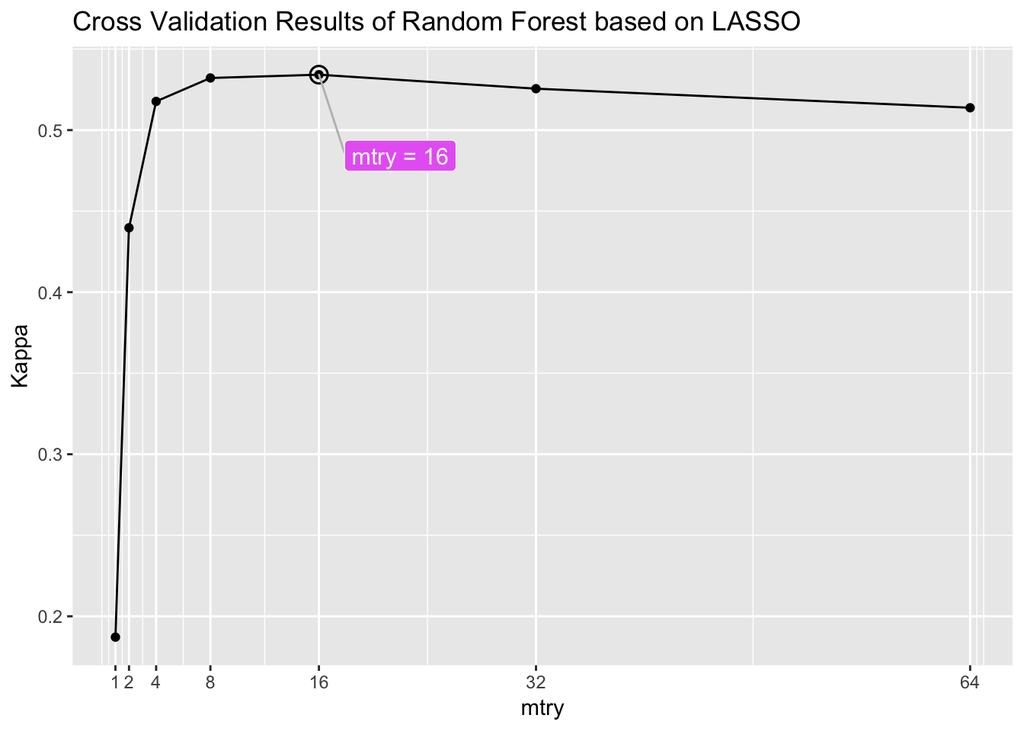

```r
# demonstrate cross validation results, create a plot of Kappa against mtry
rf <- rf_gridsearch$results
tune.best <- rf[order(rf$Kappa, decreasing = T)[1],]
ggplot(rf, aes(mtry, Kappa)) + geom_point() + geom_line() +
  geom_point(data = tune.best, col="black", size=3.5, stroke = 0.8, shape=21) +
  scale_x_continuous(breaks = c(1,2,4,8,16,32,64)) +
  geom_label_repel(data = tune.best, label = "mtry = 16", color = 'white',
                   fill = hue_pal()(5)[5], segment.color="grey", nudge_x = 6, nudge_y = -0.05, size = 4) + ggtitle("Cross Validation Results of Random Forest based on LASSO")
```

From this plot, we can see that Kappa increases fast when mtry changes from 1 to 8 and decreases slightly after reaching its maximum at mtry = 16. So we will use mtry = 16 to predict on test dataset.

```r
pred_lassoRF <- predict(rf_gridsearch, as.matrix(test.dtm))
# prediction accuracy
sum(pred_lassoRF==test_labels_use$toxic)/length(pred_lassoRF)
```

```
## [1] 0.6606333
```

```r
# confusion matrix
pred_lassoRF <- ifelse(pred_lassoRF==0,"pred_non_toxic","pred_toxic")
test_toxic <- ifelse(test_labels_use$toxic==0,"expect_non_toxic","expect_toxic")
table_lassoRF <- table(pred_lassoRF,test_toxic)
print(table_lassoRF)
```

```
##                 test_toxic
## pred_lassoRF     expect_non_toxic expect_toxic
##   pred_non_toxic            37145          969
##   pred_toxic                20743         5121
```

```r
# marginal percentage
prop_table_lassoRF <- prop.table(table_lassoRF,2)
print(prop_table_lassoRF)
```

```
##                 test_toxic
## pred_lassoRF     expect_non_toxic expect_toxic
##   pred_non_toxic        0.6416701    0.1591133
##   pred_toxic            0.3583299    0.8408867
```

The diagnoal of the above confusion matrix represent specificity ($=64.2\%$) and sensitivity ($=84.1\%$). The overall prediction accuracy of random forest is around $66.1\%$.

### 4.2.2 LASSO –> Linear SVM

Next, we train SVM models with linear kernel.

```r
set.seed(111)
trCtl = trainControl(method = "cv")
tg <- data.frame(C=c(0.1,0.5,1,10))
fit_svmLinear = train(x = dense.train.dtm,
                      y = as.factor(train.sample$toxic),
                      method = "svmLinear",
                      tuneGrid = tg,
                      trControl = trCtl)
```

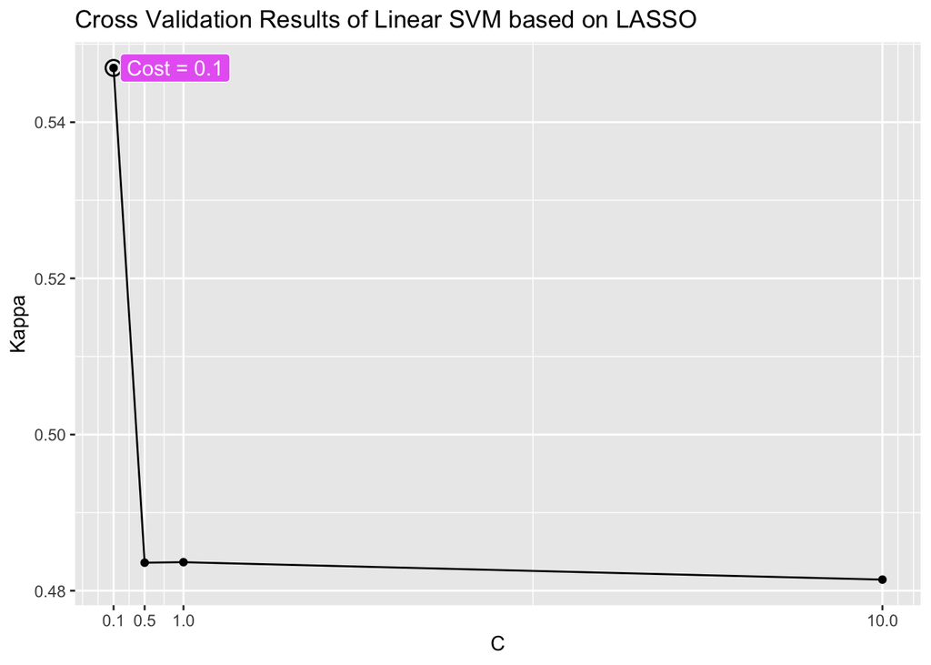

```r
# demonstrate cross validation results, create a plot of Kappa against cost
tune.best <- lsvm_results[order(lsvm_results$Kappa, decreasing = T)[1],]
ggplot(lsvm_results, aes(C, Kappa)) + geom_point() + geom_line() +
  geom_point(data = tune.best, col="black", size=3.5, stroke = 0.8, shape=21) +
  scale_x_continuous(breaks = c(0.1,0.5,1,10)) +
  geom_label_repel(data = tune.best, label = "Cost = 0.1", color = 'white',
                   fill = hue_pal()(5)[5], segment.color="grey", nudge_x = 0.5, size = 4) +
  ggtitle("Cross Validation Results of Linear SVM based on LASSO")
```

Based on cross validation results, we obtain the best Kappa when cost equals to 0.1. Also, Kappa has a large drop when cost becomes 0.5. We then use linear SVM with cost = 0.1 to predict toxicity/nontoxicity.

```r
pred_lassoSVMlinear = predict(fit_svmLinear, as.matrix(test.dtm))
# prediction accuracy
sum(pred_lassoSVMlinear==test_labels_use$toxic)/length(pred_lassoSVMlinear)
```

```
## [1] 0.6510519
```

```r
# confusion matrix
pred_lassoSVMlinear <- ifelse(pred_lassoSVMlinear==0,"pred_non_toxic","pred_toxic")
table_lassoSVMlinear <- table(pred_lassoSVMlinear, test_toxic)
print(table_lassoSVMlinear)
```

```
##                    test_toxic
## pred_lassoSVMlinear expect_non_toxic expect_toxic
##      pred_non_toxic            36497          934
##      pred_toxic                21391         5156
```

```r
# marginal percentage
prop_table_lassoSVMlinear <- prop.table(table_lassoSVMlinear,2)
print(prop_table_lassoSVMlinear)
```

```
##                    test_toxic
## pred_lassoSVMlinear expect_non_toxic expect_toxic
##      pred_non_toxic        0.6304761    0.1533662
##      pred_toxic            0.3695239    0.8466338
```

### 4.2.3 LASSO –> RBF SVM

Then, we consider the SVM model with radial basis function (RBF) kernel.

```r
set.seed(111)
trCtl = trainControl(method = "cv")
tg <- expand.grid(C = seq(10,100,10), sigma = c(0.5,1,1.5,2,3,4,5,7,9))
fit_svmRadial = train(x = dense.train.dtm,
                      y = as.factor(train.sample$toxic),
                      method = "svmRadial",
                      tuneGrid = tg,
                      trControl = trCtl)
```

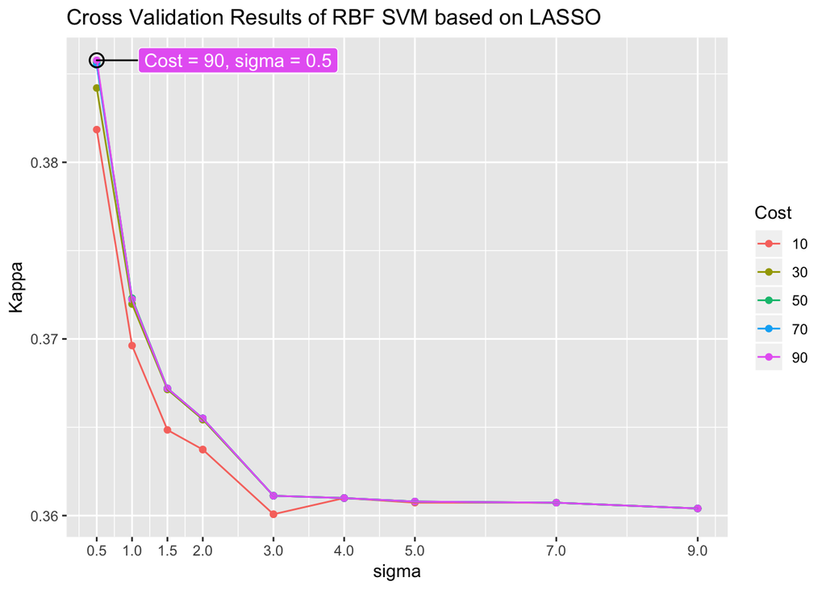

```r
tune.best = rsvm_results[order(rsvm_results$Kappa, decreasing = T)[1],]
# Kappa plot
ggplot(rsvm_results, aes(sigma, Kappa, col = factor(C))) + geom_point() + geom_line() +
  geom_point(data = tune.best, col="black", size=3.5, stroke = 0.8, shape=21) +
  labs(color = "Cost") + scale_x_continuous(breaks = c(0.5,1,1.5,2,3,4,5,7,9)) +
  geom_label_repel(data = tune.best, label = "Cost = 90, sigma = 0.5", color = 'white',
                   fill = hue_pal()(5)[5], segment.color="black", nudge_x = 2, size = 4) +
  ggtitle("Cross Validation Results of RBF SVM based on LASSO")
```

Each line on above plot represents a value of cost function we used to tune RBF SVM model. We can see that lines have similar trends as sigma becomes large, which implies that cost function does not have much influence on Kappa. However, Kappa is clearly sensitive to the choices of sigma. The combination of cost = 90 and sigma = 0.5 yields the best value of Kappa. We will then use this combination to obtain prediction results.

```r
pred_lassoSVMRadial = predict(fit_svmRadial, as.matrix(test.dtm))
# prediction accuracy
sum(pred_lassoSVMRadial==test_labels_use$toxic)/length(pred_lassoSVMRadial)
```

```
## [1] 0.6728094
```

```r
# confusion matrix
pred_lassoSVMRadial <- ifelse(pred_lassoSVMRadial==0,"pred_non_toxic","pred_toxic")
table_lassoSVMRadial <- table(pred_lassoSVMRadial,test_toxic)
print(table_lassoSVMRadial)
```

```
##                    test_toxic
## pred_lassoSVMRadial expect_non_toxic expect_toxic
##      pred_non_toxic            38676         1721
##      pred_toxic                19212         4369
```

```r
# marginal percentage
prop_table_lassoSVMRadial <- prop.table(table_lassoSVMRadial,2)
print(prop_table_lassoSVMRadial)
```

```
##                    test_toxic
## pred_lassoSVMRadial expect_non_toxic expect_toxic
##      pred_non_toxic        0.6681177    0.2825944
##      pred_toxic            0.3318823    0.7174056
```